# Expedia Training Data-set Analysis

SarahLynne Palomo

06/05/2021

## Exploring **NULL** values

```r
# Load Training data-set
tr <- read.csv("training_set_VU_DM.csv")

#which(is.null(tr$srch_id))  # <-- this does not work!
#which(tr$srch_id == "NULL")  # Not a real NULL value; it's a string
#which(tr$comp3_rate == "NULL") # testing function on a column that contains "NULL"

# Create a new table for analyzing NULL stats
df_null_ratios <- data.frame(matrix(ncol = 3, nrow = 54))
names(df_null_ratios) <- list("Column_Name", "NULL_Count", "NULL_Percentage")

tr_row <- nrow(tr)
tr_col <- ncol(tr)
i <- 0

for (i in 1:tr_col) {
  # Populate column names from the training set into new table
  df_null_ratios[i, 1] <- names(tr)[i]

  # Find the rows in the training set that contain string "NULL"
  null_rows <- which(tr[,i] == "NULL")

  # Populate "NULL" counts into new table
  num_nulls <- nrow(as.matrix(null_rows))
  df_null_ratios[i, 2] <- num_nulls

  # Populate percentage of counts into new table
  null_perc <- (num_nulls / tr_row) * 100
  df_null_ratios[i, 3] <- null_perc
}

# Table of NULLs per attribute
df_null_ratios
```

| Column_Name | NULL_Count | NULL_Percentage |
| --- | --- | --- |
| srch_id | 0 | 0.00000 |
| date_time | 0 | 0.00000 |
| site_id | 0 | 0.00000 |
| visitor_location_country_id | 0 | 0.00000 |
| visitor_hist_starrating | 4706481 | 94.92036 |
| visitor_hist_adr_usd | 4705359 | 94.89774 |
| prop_country_id | 0 | 0.00000 |
| prop_id | 0 | 0.00000 |
| prop_starrating | 0 | 0.00000 |
| prop_review_score | 0 | 0.00000 |

[output cut: 44 more lines]

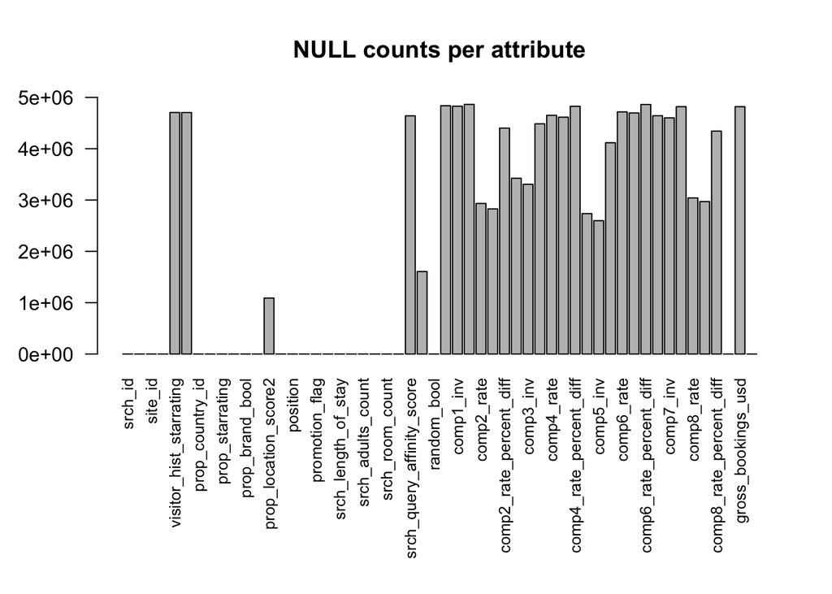

```r
# Barplot of NULLs per attribute
par(mar=c(10,4,4,2) + 0.1)
barplot(df_null_ratios$NULL_Count, names.arg = df_null_ratios$Column_Name, horiz = FALSE, las=2, cex.names=0.8, ylim = c(0,5000000), main = "NULL counts per attribute")
```

Check the variables containing more than 90% NULL values against the following descriptions of the data-set for significance! (e.g. Not all NULLs can be converted to 0 since these would become actual values.)

| # Data-set Variables |
| --- |
| ## Exploring **srch_id** *Data Type:* integer *Description:* The ID of the search |
| `r # Find unique search id's and count how many of them are in the submission_sample data-set uniq_srch <- unique(tr$srch_id) num_uniq_srch <- nrow(as.matrix(uniq_srch)) head(uniq_srch, 10)` |
| `## [1] 1 4 6 8 11 12 17 21 25 28` |
| `r tail(uniq_srch, 10)` |
| `## [1] 332765 332768 332772 332774 332776 332777 332781 332782 332784 332785` |
| `r last_srch_id <- tail(uniq_srch, n=1) # Highest srch_id in (incidentally) ascending list perc_missing_srch <- (1 - (num_uniq_srch / last_srch_id)) * 100 perc_missing_srch` |
| `## [1] 39.96274` *Observations:* Here, we can see that a good portion of *srch_id* values are missing from the training data-set sequence (40%) |

## Exploring **date_time**

*Data Type:* Date/time *Description:* Date and time of the search

```r
min(tr$date_time)
```

```
## [1] "2012-11-01 00:08:29"
```

```r
max(tr$date_time)
```

```
## [1] "2013-06-30 23:58:24"
```

*Observations:* Dates are not in sequential order. It may be necessary to split *date_time* field into Date and Time fields. (Kaggle competition host says this is browser time of the user making a query)

[output not shown]

## Exploring **visitor_location_country_id**

*Data Type:* Integer *Description:* The ID of the country the customer is located

```r
uniq_visitor_country <- unique(tr$visitor_location_country_id)
sort(uniq_visitor_country)
```

```
##   [1]   1   2   3   4   5   6   7   9  10  11  12  13  14  15  16  17  18  19
##  [19]  20  21  22  23  25  26  27  28  29  30  31  32  33  34  35  36  37  38
##  [37]  39  40  41  42  44  45  46  47  48  50  51  52  53  54  55  56  57  58
##  [55]  59  60  61  62  63  64  65  66  67  68  69  70  71  72  73  74  76  77
##  [73]  78  79  80  81  82  83  84  85  86  87  88  90  91  92  93  94  95  97
##  [91]  98  99 100 101 102 103 105 106 107 108 109 110 111 112 113 114 115 116
## [109] 117 118 120 121 122 123 125 126 127 128 129 130 131 132 133 134 135 136
## [127] 137 138 139 140 142 145 146 148 149 150 151 152 153 154 155 156 157 158
## [145] 160 161 162 163 164 166 167 168 169 170 172 173 174 176 177 178 179 180
## [163] 181 182 183 184 185 186 187 188 189 190 191 193 194 195 196 198 199 200
## [181] 201 202 203 204 205 206 207 208 209 210 211 212 213 214 215 216 217 218
## [199] 219 220 221 222 223 224 226 227 228 229 230 231
```

```r
num_uniq_v_country <- nrow(as.matrix(uniq_visitor_country))
max_uniq_v_country <- max(uniq_visitor_country)
missing_v_countries_perc <- (max_uniq_v_country - num_uniq_v_country) / max_uniq_v_country * 100
missing_v_countries_perc
```

```
## [1] 9.090909
```

*Observations:* 9% of visitor countries are missing from the data-set. *TODO:* check whether *visitor_location_country_id* is specific to *srch_id*

## Exploring **visitor_hist_starrating** *Data Type:* Float *Description:* The mean star rating of hotels the customer has previously purchased; null signifies there is no purchase history on the customer

`r # Find the range of mean hotel rating scores of the non-NULL set vhs <- subset(tr$visitor_hist_starrating, tr$visitor_hist_starrating != "NULL") vhs <- as.numeric(vhs) range(vhs)`

`## [1] 1.41 5.00`

`r hist(vhs, xlab = "visitor_hist_starrating", main = "Histogram of mean hotel rating scores")`

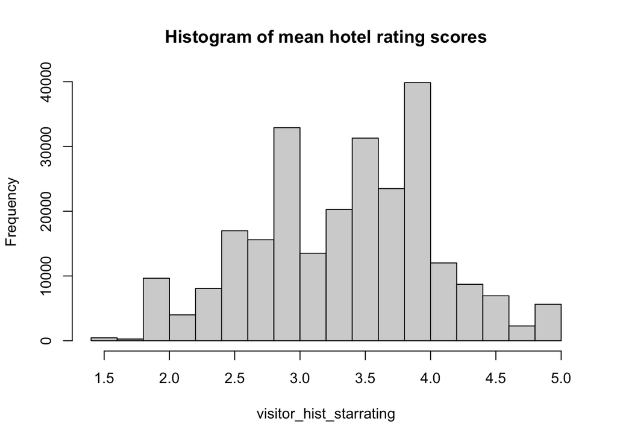

*Observations:* 94.9% NULL values. Note that the mean hotel rating (*visitor_hist_starrating*) is specific to an individual (*srch_id*). *TODO:* change NULL values to -1 since this is an invalid rating and it can be ignored by the algorithm

## Exploring **visitor_hist_adr_usd**

*Data Type:* Float *Description:* The mean price per night (in US$) of the hotels the customer has previously purchased; null signifies there is no purchase history on the customer

```r
# Find the range of mean USD price per night of the non-NULL set
vha_usd <- subset(tr$visitor_hist_adr_usd, tr$visitor_hist_adr_usd != "NULL")
vha_usd <- as.numeric(vha_usd)
range(vha_usd)
```

```
## [1]    0.0 1958.7
```

```r
# Find the 0's in the data-set
subset(vha_usd, vha_usd == 0)
```

```
##  [1] 0 0 0 0 0 0 0 0 0 0 0 0 0 0 0 0 0 0 0 0 0 0 0 0 0 0 0 0 0 0 0 0 0 0 0 0 0 0
## [39] 0
```

```r
vha_usd0 <- subset(vha_usd, vha_usd == 0)
nrow(as.matrix(vha_usd0))  # 39 zeroes in data-set
```

```
## [1] 39
```

```r
# Index of rows in original data-set where variable equals 0
which(as.numeric(tr$visitor_hist_adr_usd) == 0)
```

```
##  [1] 4321990 4321991 4321992 4321993 4321994 4321995 4321996 4321997 4321998
## [10] 4321999 4322000 4322001 4724870 4724871 4724872 4724873 4724874 4724875
## [19] 4724876 4724877 4724878 4724879 4724880 4724881 4724882 4724883 4724884
## [28] 4724885 4724886 4724887 4724888 4724889 4724890 4724891 4724892 4724893
## [37] 4724894 4724895 4724896
```

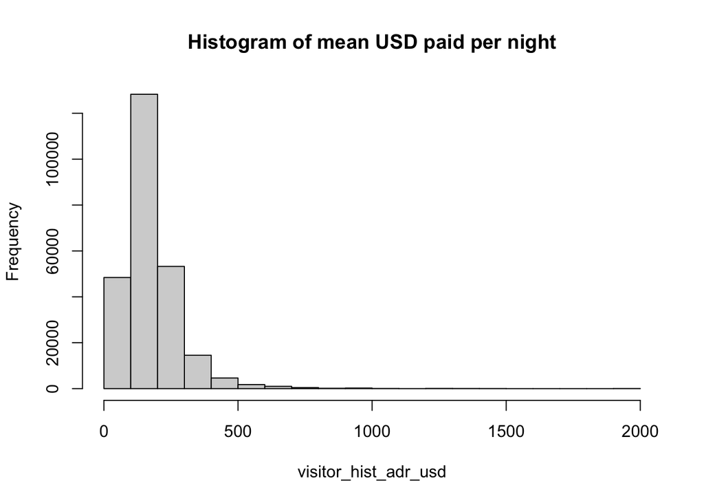

```r
hist(vha_usd, xlab = "visitor_hist_adr_usd", main = "Histogram of mean USD paid per night")
```

| ## Exploring **prop_country_id** *Data Type:* Integer *Description:* The ID of the country the hotel is located in |
| --- |
| `r uniq_prop_country <- unique(tr$prop_country_id) sort(uniq_prop_country)` |
| `## [1] 1 2 4 7 9 10 11 13 14 15 16 17 18 19 20 21 22 23 ## [19] 25 26 27 30 31 32 33 34 35 37 38 39 40 41 42 44 45 46 ## [37] 47 48 50 51 53 55 56 57 59 60 61 62 63 65 68 69 70 71 ## [55] 72 73 74 76… |
| `r nrow(as.matrix(uniq_prop_country)) # 230` |
| `## [1] 172` |
| `r (230-172) / 230 * 100` |
| `## [1] 25.21739` *Observations:* 58/230 of property countries are missing from the data-set sequence (25%). *prop_country_id* is specific to *prop_id* |

## Exploring **prop_id**

*Data Type:* Integer Description: The ID of the hotel

```r
uniq_prop_id <- unique(tr$prop_id)
#sort(uniq_prop_id)
nrow(as.matrix(uniq_prop_id))  # 129113
```

```
## [1] 129113
```

```r
range(uniq_prop_id)  # 1 to 140821
```

```
## [1]      1 140821
```

```r
(140821 - 129113) / 140821 * 100
```

```
## [1] 8.314101
```

*Observations:* 11708/140821 of property id’s are missing from from the data-set sequence (8.3%).

## Exploring **prop_starrating** *Data Type:* Integer *Description:* The star rating of the hotel, from 1 to 5, in increments of 1. A 0 indicates the property has no stars, the star rating is not known or cannot be publicized

`r nrow(as.matrix(tr$prop_starrating))`

`## [1] 4958347`

`r hist(tr$prop_starrating, main = "Histogram of hotel star ratings")`

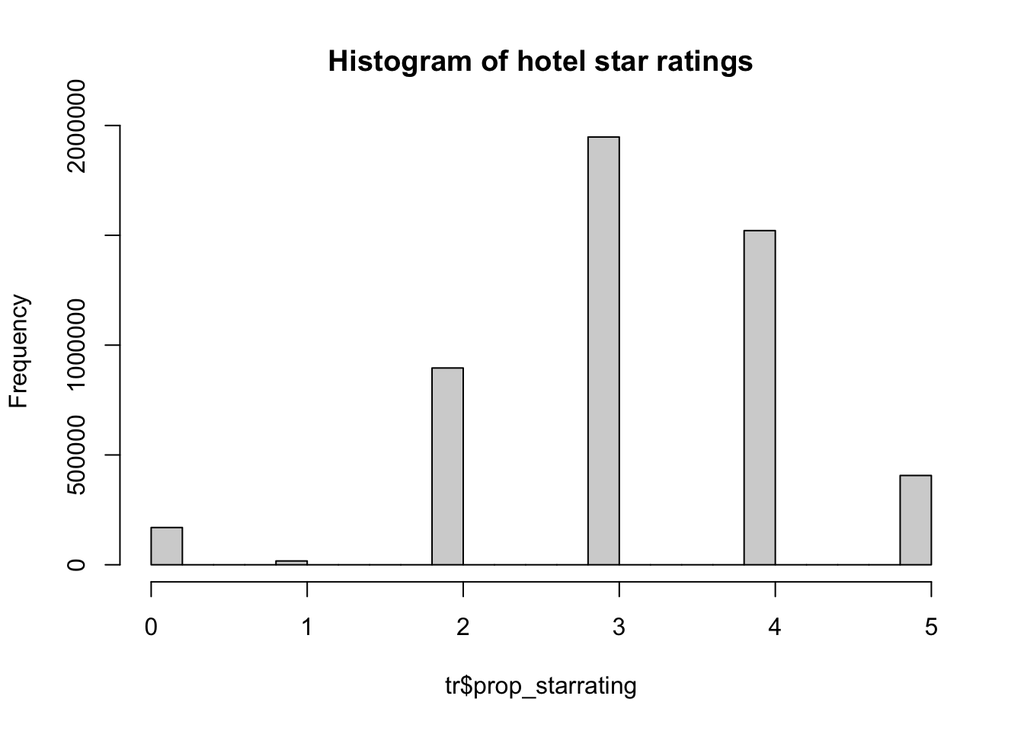

`r prop_nostars <- subset(tr$prop_starrating, tr$prop_starrating == 0) nrow(as.matrix(prop_nostars))`

`## [1] 169572`

`r 169572 / 4958347 * 100`

`## [1] 3.41993`

*Observations:* Property star rating (*prop_starrating*) is specific to each property listing (*prop_id*). Most properties are rated 3 stars. 169572/4958347 of property listings have 0 stars (3.4%)

## Exploring **prop_review_score**

*Data Type:* Float *Description:* The mean customer review score for the hotel on a scale out of 5, rounded to 0.5 increments. A 0 means there have been no reviews, null that the information is not available

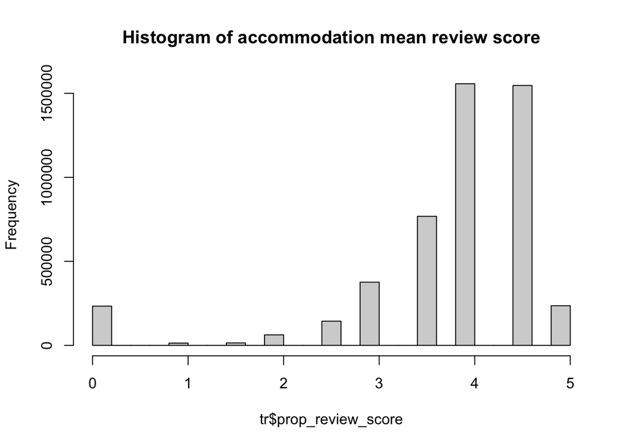

```r
#subset(tr$prop_review_score, tr$prop_id == 10404)  # example hotel
hist(tr$prop_review_score, main = "Histogram of accommodation mean review score")
```

```r
subset(tr, is.null(tr$prop_review_score))
```

| srch_id | date_time | site_id | visitor_location_country_id | visitor_hist_starrating | visitor_hist_adr_usd | prop_country_id | prop_id | prop_starrating | prop_review_score | prop_brand_bool | prop_location_score1 | prop_location_score2 | prop_log_historical_price | position | price_usd | promotion_flag | srch_destination_id | srch_length_of_stay | srch_booking_window | srch_adults_count | srch_children_count | srch_room_count | srch_saturday_night_bool | srch_query_affinity_score | orig_destination_distance | random_bool | comp1_rate | comp1_inv | comp1_rate_percent_diff | … |
| --- | --- | --- | --- | --- | --- | --- | --- | --- | --- | --- | --- | --- | --- | --- | --- | --- | --- | --- | --- | --- | --- | --- | --- | --- | --- | --- | --- | --- | --- | --- |

*Observations:* *prop_review_score* is specific to *prop_id*. Majority rating is 4.0 closely followed by 4.5. No null values found.

## Exploring **prop_brand_bool** *Data Type:* Integer *Description:* +1 if the hotel is part of a major hotel chain; 0 if it is an independent hotel

`r hist(tr$prop_brand_bool, main = "Major hotel chain (1) vs independent hotel (0)")`

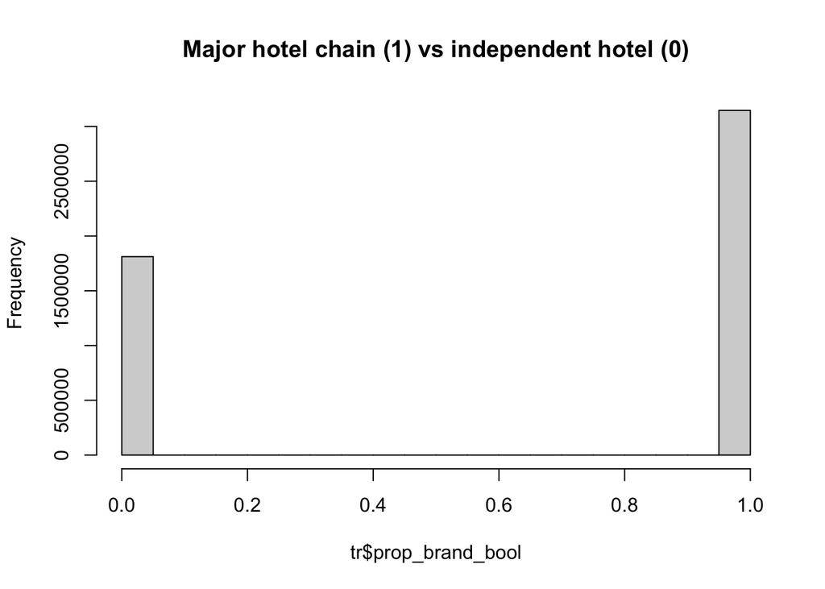

`r chain_hotel <- subset(tr$prop_brand_bool, tr$prop_brand_bool == 1) nrow(as.matrix(chain_hotel)) # 3147060`

`## [1] 3147060`

`r ind_hotel <- subset(tr$prop_brand_bool, tr$prop_brand_bool == 0) nrow(as.matrix(ind_hotel)) # 1811287`

`## [1] 1811287`

`r nrow(as.matrix(tr$prop_brand_bool))`

`## [1] 4958347`

`r 3147060 / 4958347 * 100`

`## [1] 63.46994`

`r 1811287 / 4958347 * 100`

`## [1] 36.53006`

*Observations:* Hotel chains make up the majority of accommodation listings (63.5%) compared to independent hotels (36.5%)

## Exploring **prop_location_score1**

*Data Type:* Float *Description:* A (first) score outlining the desirability of a hotel’s location

```r
range(tr$prop_location_score1)
```

```
## [1] 0.00 6.98
```

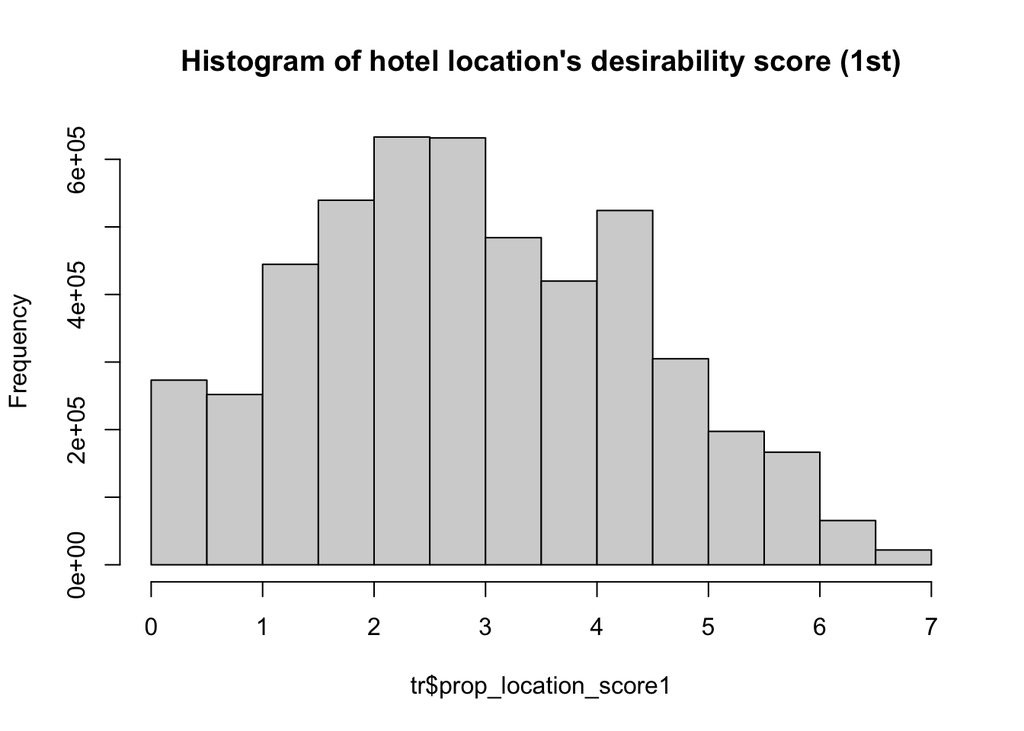

```r
hist(tr$prop_location_score1, main = "Histogram of hotel location's desirability score (1st)")
```

*Observations:* First score only goes up to 6.98 (out of what total??). *Questions:* What is better: a high or low score? Is this score visible to the customer while booking on the website? (Guido’s answer: don’t know; no information is availble on the kaggle site)

## Exploring **prop_location_score2** *Data Type:* Float *Description:* A (second) score outlining the desirability of the hotel’s location

`r pls2 <- subset(tr$prop_location_score2, tr$prop_location_score2 != "NULL") pls2 <- as.numeric(pls2) range(pls2)`

`## [1] 0 1`

`r hist(pls2, xlab = "prop_location_score2", main = "Histogram of hotel location's desirability score (2nd)")`

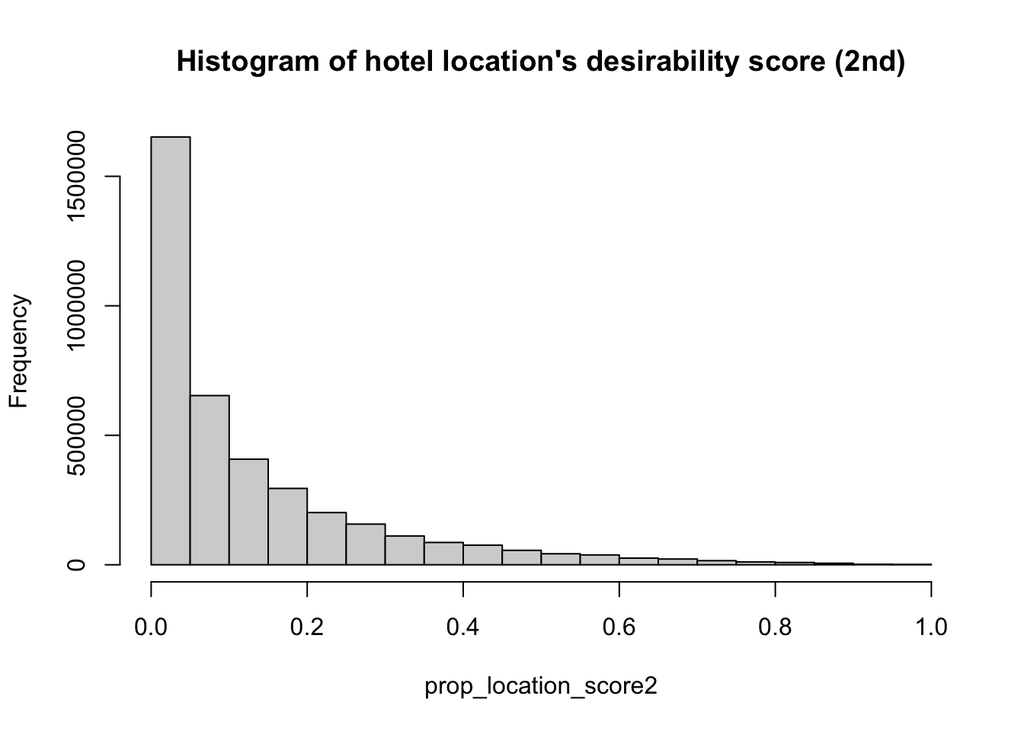

*Observations:* 22% NULL values. Histogram does not include nulls. Second score data appear to be logarithmic. *Questions:* Why have a second score? What is it for compared to the first score? (Guido’s answer: don’t know but don’t disregard these features as they may still be useful). (Kaggle competition host: “Score1 and Score2 are postively correlated”, https://www.kaggle.com/c/expedia-personalized-sort/discussion/5854 ) *TODO:* change NULLs to -1 (these do not fall into the 0:1 range and can be ignored by the algorithm)

## Exploring **prop_log_historical_price**

*Data Type:* Float *Description:* The logarithm of the mean price of the hotel over the last trading period. A 0 will occur if the hotel was not sold in that period

```r
range(tr$prop_log_historical_price)
```

```
## [1] 0.00 6.21
```

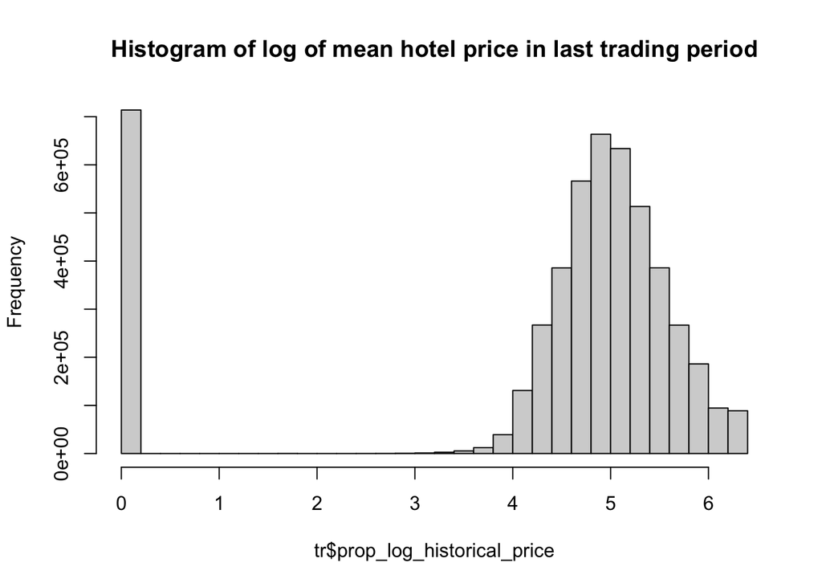

```r
hist(tr$prop_log_historical_price, main = "Histogram of log of mean hotel price in last trading period")
```

*Observations:* Plot of mean hotel price has a somewhat normal form *Questions:* What is the definition for the last trading period? (Guido’s answer: don’t know)

## Exploring **price_usd**

*Data Type:* Float *Description:* Displayed price of the hotel for the given search. Note that different countries have different conventions regarding displaying taxes and fees and the value may be per night or for the whole stay

```r
range(tr$price_usd)  # 0 to 19726328  <--- seriously... WTF?
```

```
## [1]        0 19726328
```

```r
which.max(tr$price_usd)  # find the row index of this *ridiculously expensive* hotel
```

```
## [1] 1168567
```

```r
tr[1168567,]  # data-set entry for the most expensive hotel of them all
```

|  | srch_id | date_time | site_id | visitor_location_country_id | visitor_hist_starrating | visitor_hist_adr_usd | prop_country_id | prop_id | prop_starrating | prop_review_score | prop_brand_bool | prop_location_score1 | prop_location_score2 | prop_log_historical_price | position | price_usd | promotion_flag | srch_destination_id | srch_length_of_stay | srch_booking_window | srch_adults_count | srch_children_count | srch_room_count | srch_saturday_night_bool | srch_query_affinity_score | orig_destination_distance | random_bool | comp1_rate | comp1_inv | … |
| --- | --- | --- | --- | --- | --- | --- | --- | --- | --- | --- | --- | --- | --- | --- | --- | --- | --- | --- | --- | --- | --- | --- | --- | --- | --- | --- | --- | --- | --- | --- |
| 1168567 | 78107 | 2013-06-17 17:32:48 | 5 | 202 | NULL | NULL | 39 | 39677 | 5 | 5 | 1 | 2.4 | 0.0074 | 0 | 12 | 19726328 | 0 | 15122 | 4 | 7 | 2 | 1 | 1 | 0 | NULL | NULL | 0 | NULL | NULL | … |

```r
price_hotel <- subset(tr$price_usd, tr$price_usd > 0)
price_hotel <- sort(price_hotel)
tail(price_hotel)   # looks like it wasn't just an outlier. Wow. Who books this stuff online??
```

```
## [1]  4884239  4973355  5444467  9381309 11818011 19726328
```

```r
head(price_hotel)
```

```
## [1] 0.01 0.01 0.01 0.01 0.01 0.01
```

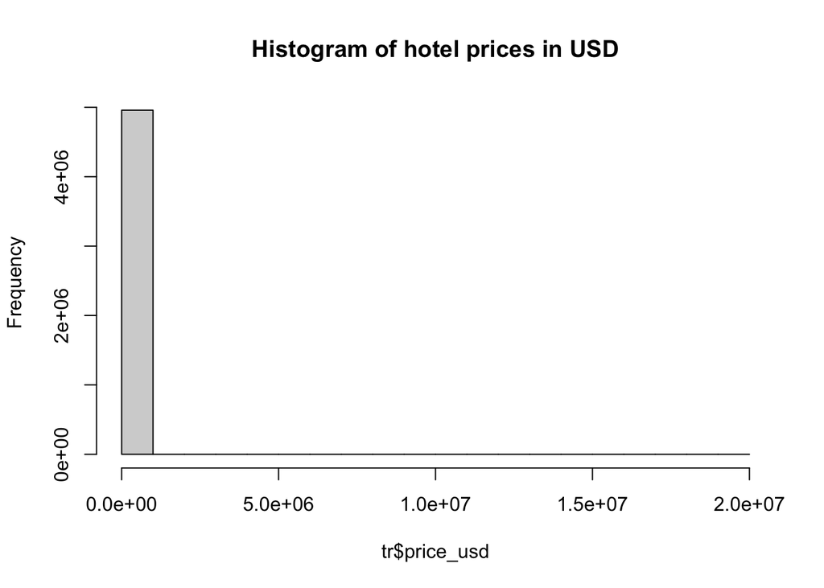

```r
hist(tr$price_usd, main = "Histogram of hotel prices in USD")
```

*Observations:* Need to check *price_usd* against *site_id* and *srch_length_of_stay* to normalise the value to per night due to different taxes and fees per country. There are lots of 0’s and weird values that increment in the lower end of the data. We will definitely have to fix this. *Questions:* Are the 0 prices for searches that didn’t amount to a booking? Or is it a currency conversion error? (Guido’s answer: “I think its fair to assume that a 0 value is an error in the data.”) (Kaggle competition host suggests to remove/correct the extremely high-priced outliers)

## Exploring **promotion_flag** *Data Type:* Integer *Description:* +1 if the hotel had a sale price promotion specifically displayed

`r hist(tr$promotion_flag, main = "Histogram of promotional flag")`

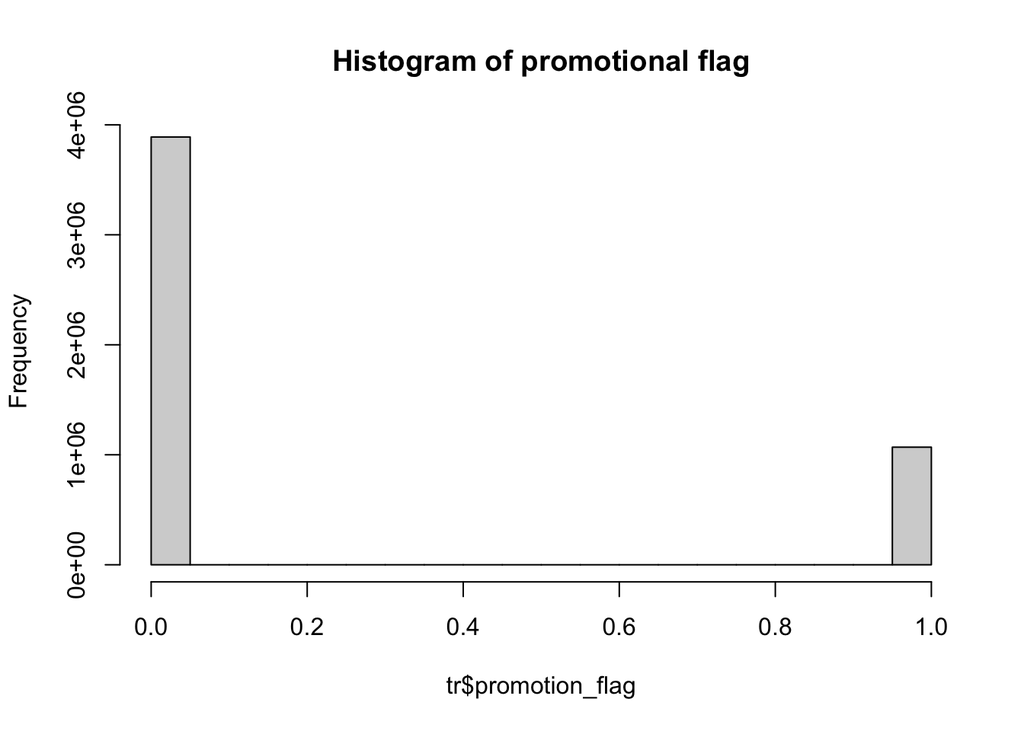

`r promo_yes <- subset(tr$promotion_flag, tr$promotion_flag == 1) nrow(as.matrix(promo_yes)) # 1069118`

`## [1] 1069118`

`r promo_no <- subset(tr$promotion_flag, tr$promotion_flag == 0) nrow(as.matrix(promo_no)) # 3889229`

`## [1] 3889229`

`r 1069118 / 4958347 * 100 # 21.6%`

`## [1] 21.56198`

`r 3889229 / 4958347 * 100 # 78.4%`

`## [1] 78.43802` *Observations:* 21.6% of accommodations are listed with a promotional sale price. This really should be type boolean instead of integer. No NULLs found.

## Exploring **srch_destination_id**

*Data Type:* Integer *Description:* ID of the destination where the hotel search was performed

```r
uniq_dest_id <- unique(tr$srch_destination_id)
uniq_dest_id <- sort(uniq_dest_id)
range(uniq_dest_id)  #   2 to 28416
```

```
## [1]     2 28416
```

```r
nrow(as.matrix(uniq_dest_id))  # 18127
```

```
## [1] 18127
```

```r
(28416 - 18127) / 28416 * 100  # 36.20847
```

```
## [1] 36.20847
```

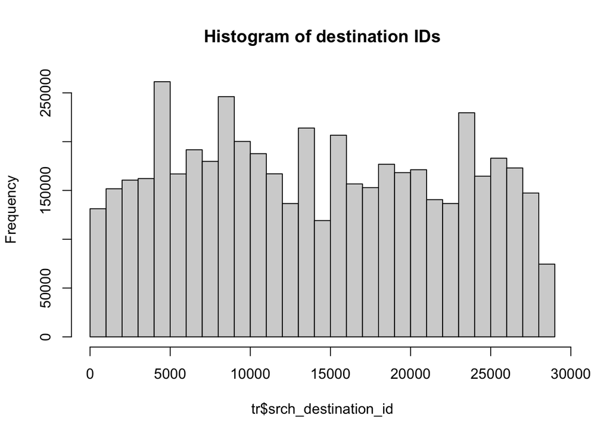

```r
hist(tr$srch_destination_id, main = "Histogram of destination IDs")
```

*Observations:* Some destinations are more popular than others. 10289/28416 of destination ids are missing from the data-set sequence (36%) *TODO:* Find out which destinations are more popular

## Exploring **srch_length_of_stay** *Data Type:* Integer *Description:* Number of nights stay that was searched

`r hist(tr$srch_length_of_stay, main = "Histogram number of nights searched (all)")`

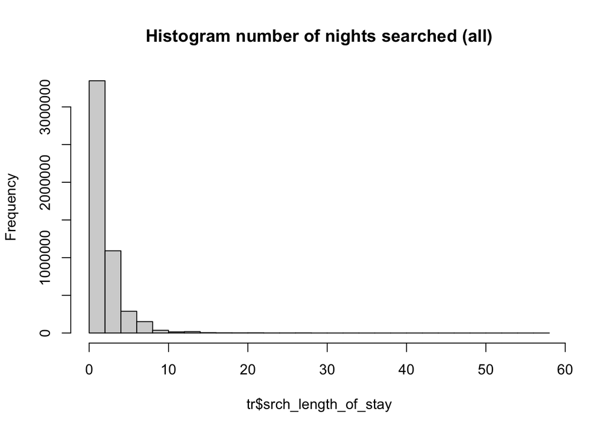

`r range(tr$srch_length_of_stay)`

`## [1] 1 57`

`r num_nights10 <- subset(tr$srch_length_of_stay, tr$srch_length_of_stay <= 10) hist(num_nights10, main = "Histogram number of nights searched (<= 10)")`

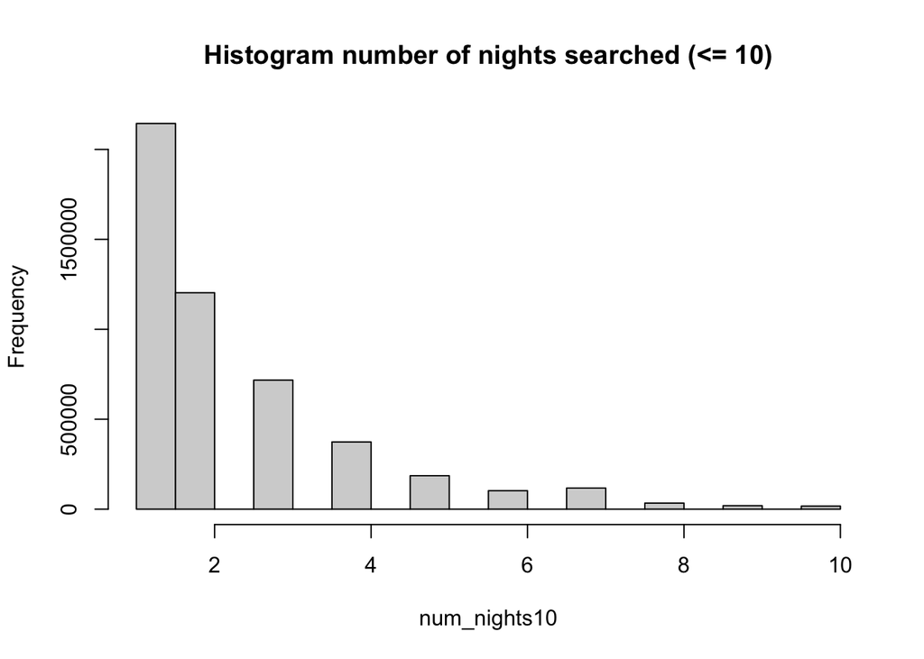

*Observations:* Data dsitribution appears logarithmic. Most common stay duration is 1 night then 2 nights.

##Exploring **srch_booking_window** *Data Type:* Integer *Description:* Number of days in the future the hotel stay started from the search date

```r
range(tr$srch_booking_window)
```

```
## [1]   0 492
```

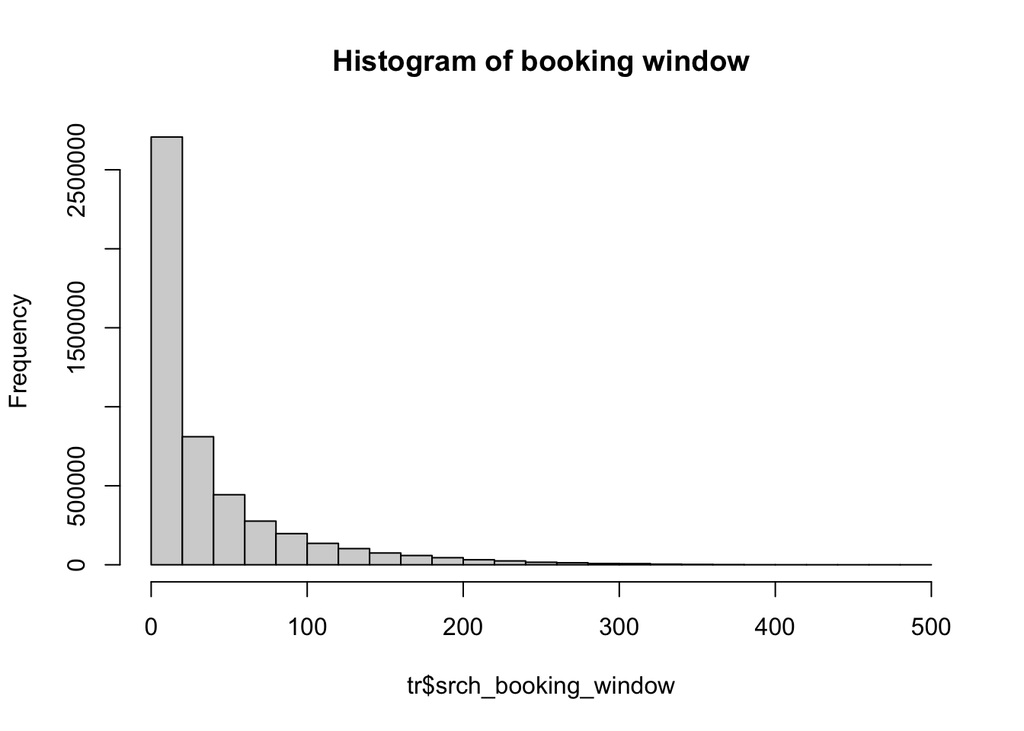

```r
hist(tr$srch_booking_window, main = "Histogram of booking window")
```

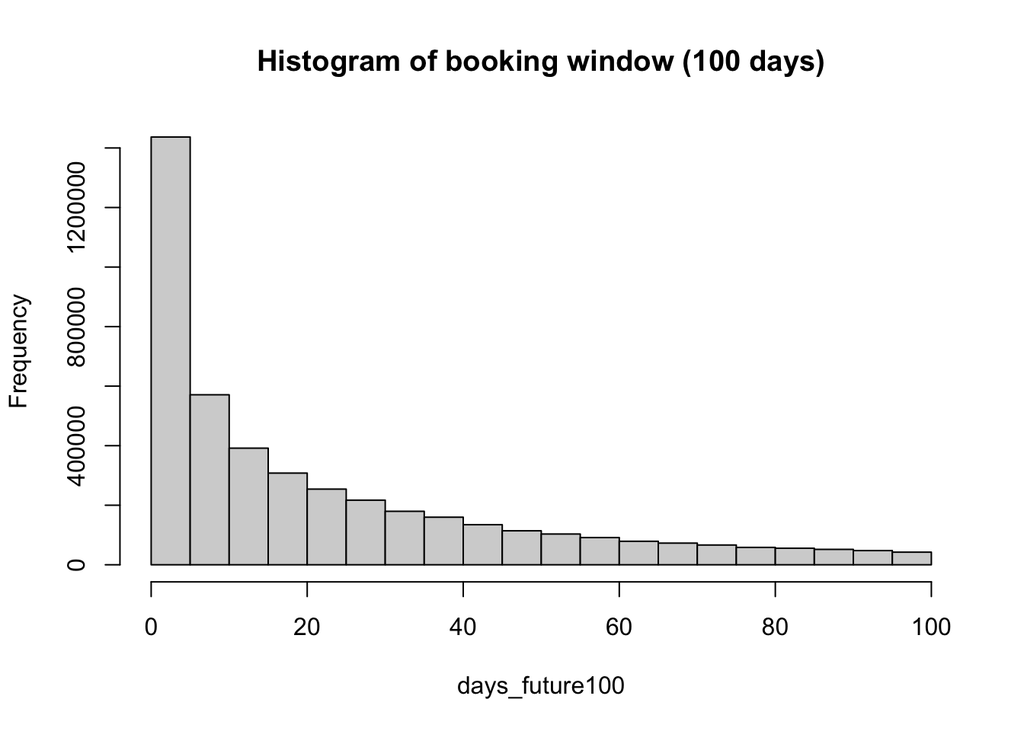

```r
days_future100 <- subset(tr$srch_booking_window, tr$srch_booking_window <= 100)
hist(days_future100, main = "Histogram of booking window (100 days)")
```

*Observations:* Data dsitribution appears logarithmic. Most common booking window is within 5 days of stay

## Exploring **srch_adults_count** *Data Type:* Integer *Description:* The number of adults specified in the hotel room

`r range(tr$srch_adults_count)`

`## [1] 1 9`

`r hist(tr$srch_adults_count, main = "Histogram of number of adults per booking")`

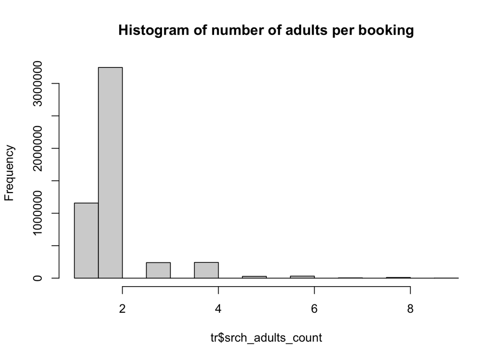

*Observations:* Most common hotel booking is for 2 adults per room.

## Exploring **srch_children_count**

*Data Type:* Integer *Description:* The number of (extra occupancy) children specified in the hotel room

```r
range(tr$srch_children_count)
```

```
## [1] 0 9
```

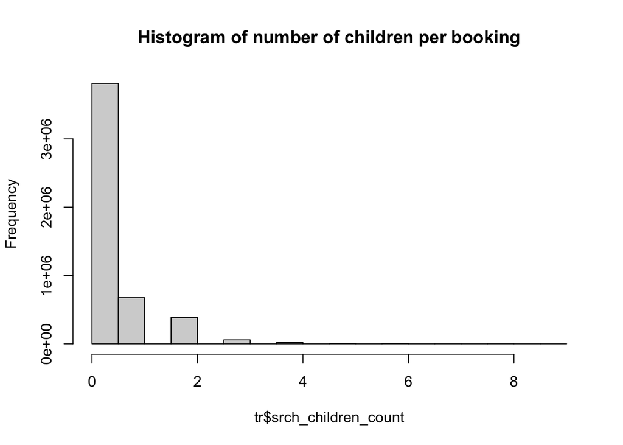

```r
hist(tr$srch_children_count, main = "Histogram of number of children per booking")
```

*Observations:* Most bookings are made without including children

## Exploring **srch_room_count** *Data Type:* Integer *Description:* Number of hotel rooms specified in the search

`r range(tr$srch_room_count)`

`## [1] 1 8`

`r hist(tr$srch_room_count, main = "Histogram of number of rooms")`

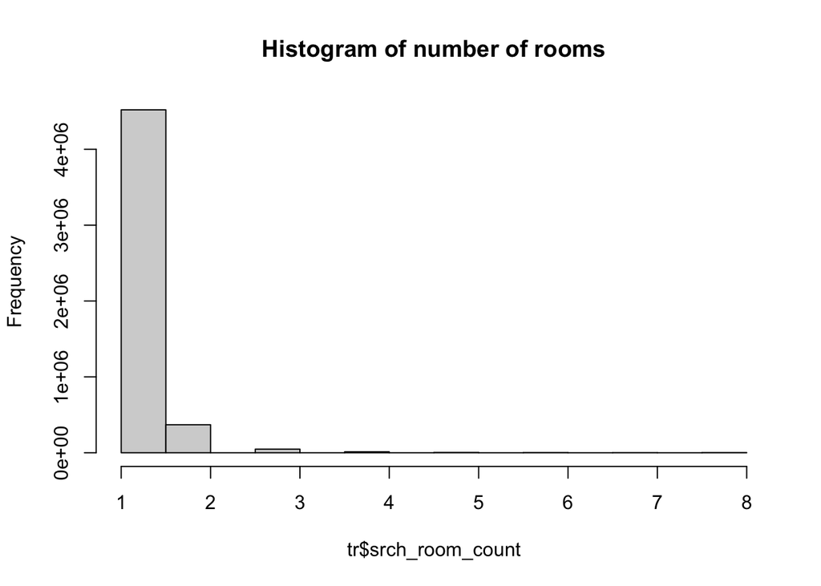

*Observations:* Vast majority of bookings are made for 1 room only

## Exploring **srch_saturday_night_bool**

*Data Type:* Boolean *Description:* +1 if the stay includes a Saturday night, starts from Thursday with a length of stay is less than or equal to 4 nights (i.e. weekend); otherwise 0

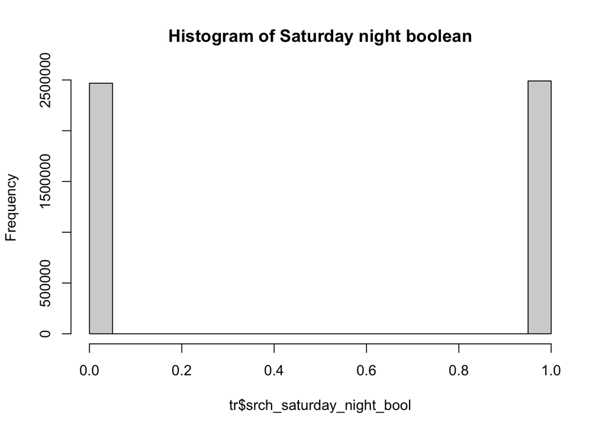

```r
hist(tr$srch_saturday_night_bool, main = "Histogram of Saturday night boolean")
```

```r
saturday_no <- subset(tr$srch_saturday_night_bool, tr$srch_saturday_night_bool == 0)
nrow(as.matrix(saturday_no))  # 2468202
```

```
## [1] 2468202
```

```r
saturday_yes <- subset(tr$srch_saturday_night_bool, tr$srch_saturday_night_bool == 1)
nrow(as.matrix(saturday_yes))  # 2490145
```

```
## [1] 2490145
```

*Observations:* Number of bookings made including Saturday night (2490145) is almost the same as excluding (2468202)

## Exploring **srch_query_affinity_score** *Data Type:* Float *Description:* The log of the probability a hotel will be clicked on in Internet searches (hence the values are negative) A null signifies there are no data (i.e. hotel did not register in any searches)

```r #range(tr$srch_query_affinity_score, na.rm = FALSE) # excluding NULL <– this doesn’t work properly

sqas <- subset(tr$srch_query_affinity_score, tr$srch_query_affinity_score != “NULL”) sqas <- as.numeric(sqas) range(sqas) ```

`## [1] -326.5675 -2.4941`

`r hist(sqas, xlab = "srch_query_affinity_score", main = "Histogram of log probability of click on hotel")`

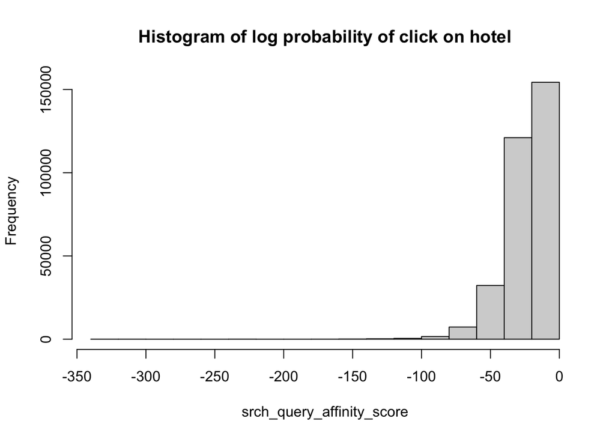

*Observations:* 93.6% of the data values are NULL. Even though the data is officially type float, it was actually type char so it first had to be converted to type numeric for the histogram and to give the correct range. Histogram excludes NULL values. *TODO:* Change NULL values to 1 (this is outside the range of -infinity:0)

## Exploring **orig_destination_distance**

*Data Type:* Float *Description:* Physical distance between the hotel and the customer at the time of search. A null means the distance could not be calculated

```r
#range(tr$orig_destination_distance)
o2d_dist <- subset(tr$orig_destination_distance, tr$orig_destination_distance != "NULL")
o2d_dist <- as.numeric(o2d_dist)
range(o2d_dist)
```

```
## [1]     0.01 11666.64
```

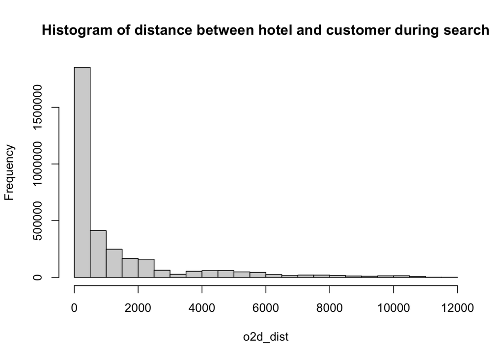

```r
hist(o2d_dist, main = "Histogram of distance between hotel and customer during search")
```

*Observations:* 32.4% of the data values are NULL. Converted type char to numeric. Histogram excludes NULL values. It’s not clear in what units the distance is calculated in. Most bookings are made when the customer is close to the hotel *TODO:* Impute the missing data from the correlation between *visitor_location_country_id* and *prop_country_id*

## Exploring **random_bool** *Data Type:* Boolean *Description:* +1 when the displayed sort was random, 0 when the normal sort order was displayed

`r hist(tr$random_bool, main = "Histogram of random boolean on display sort")`

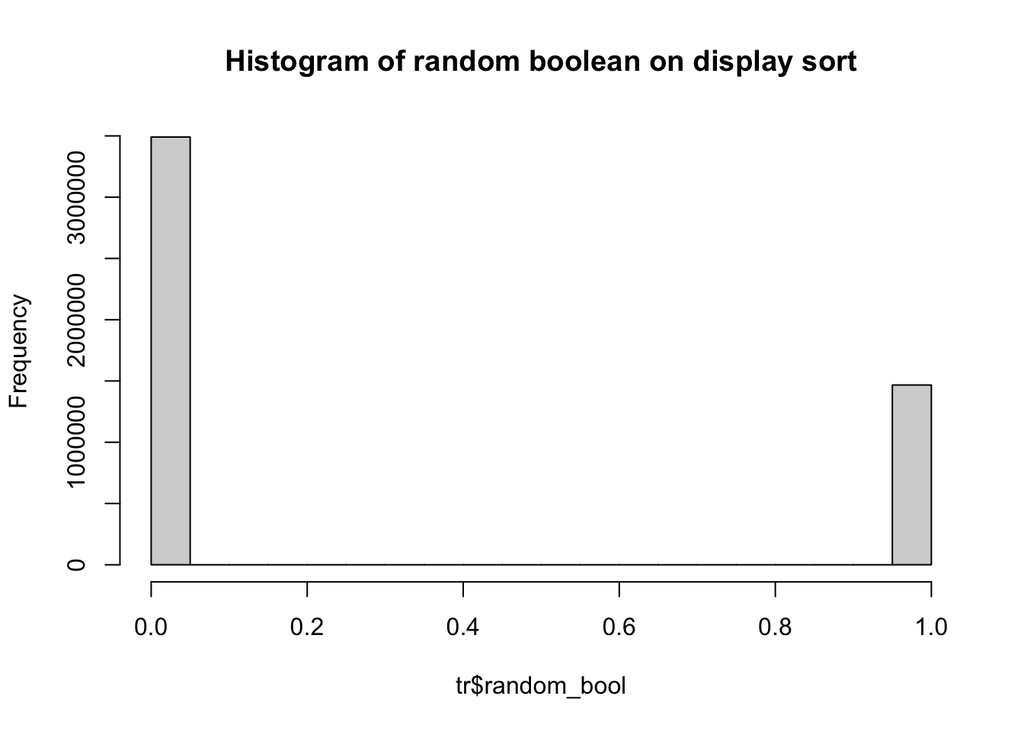

`r sort_random <- subset(tr$random_bool, tr$random_bool == 1) nrow(as.matrix(sort_random)) # 1467177`

`## [1] 1467177`

`r sort_normal <- subset(tr$random_bool, tr$random_bool == 0) nrow(as.matrix(sort_normal)) # 3491170`

`## [1] 3491170`

`r 1467177 / tr_row * 100 # 29.59004`

`## [1] 29.59004`

`r 3491170 / tr_row * 100 # 70.40996`

`## [1] 70.40996` *Observations:* Random sort display = 29.6%; Normal sort display = 70.4%

# Competitor variables

The following variables apply to competitors 1 to 8 (i.e. comp1, comp2, etc.). Values such as number of NULLs vary between them.

## Exploring **comp1_rate** *Data Type:* Integer *Description:* +1 if Expedia has a lower price than competitor 1 for the hotel; 0 if the same; -1 if Expedia’s price is higher than competitor 1; null signifies there is no competitive data

`r c1_rate <- subset(tr$comp1_rate, tr$comp1_rate != "NULL") c1_rate <- as.numeric(c1_rate) hist(c1_rate, main = "Histogram of price comparison with Competitor1")`

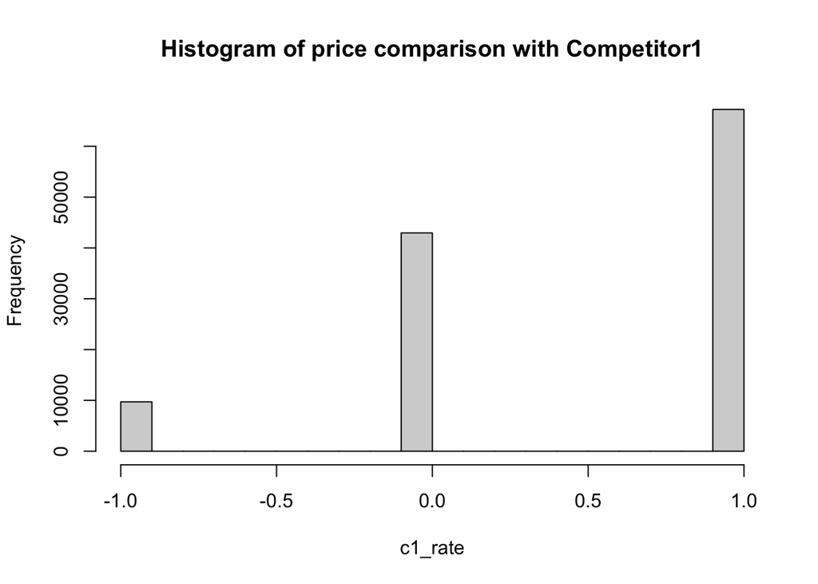

```r c1_rate_lower <- subset(c1_rate, c1_rate == 1) c1_rate_same <- subset(c1_rate, c1_rate == 0) c1_rate_higher <- subset(c1_rate, c1_rate == -1)

nrow(as.matrix(c1_rate_lower)) # 67256 ```

`## [1] 67256`

`r nrow(as.matrix(c1_rate_same)) # 42959`

`## [1] 42959`

`r nrow(as.matrix(c1_rate_higher)) # 9715`

`## [1] 9715`

`r nrow(as.matrix(c1_rate)) # 119930`

`## [1] 119930`

`r 67256 / 119930 * 100 # 56.07938`

`## [1] 56.07938`

`r 42959 / 119930 * 100 # 35.82006`

`## [1] 35.82006`

`r 9715 / 119930 * 100 # 8.100559`

`## [1] 8.100559`

*Observations:* Data contains 97.6% NULL values but we cannot change these to 0 as NULL has a meaning. Of the remaining data: 56.1% Expedia has a lower price; 35.8% Expedia’s price is the same as competitor; 8.1% Expedia has a higher price. *TODO:* Change NULL values to -2 (this is outside the range of -1:1 so it can be ignored by the algorithm)

## Exploring **comp1_inv**

*Data Type:* Integer *Description:* +1 if competitor 1 does not have availability in the hotel; 0 if both Expedia and competitor 1 have availability; null signifies there is no competitive data

```r
c1_inv <- subset(tr$comp1_inv, tr$comp1_inv != "NULL")
c1_inv <- as.numeric(c1_inv)
range(c1_inv, na.rm = TRUE)  #  -1 to 1
```

```
## [1] -1  1
```

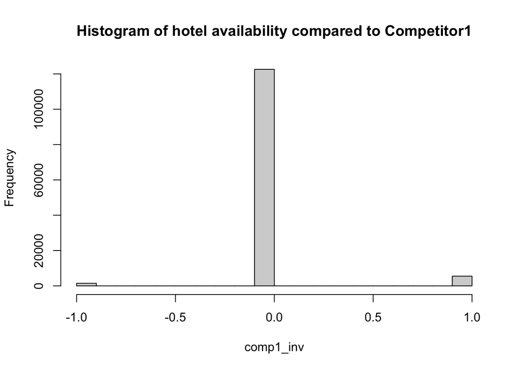

```r
hist(c1_inv, xlab = "comp1_inv", main = "Histogram of hotel availability compared to Competitor1")
```

```r
c1_inv_yes <- subset(c1_inv, c1_inv == 1)
c1_inv_both <- subset(c1_inv, c1_inv == 0)
c1_inv_no <- subset(c1_inv, c1_inv == -1)

nrow(as.matrix(c1_inv_yes))   # 5492
```

```
## [1] 5492
```

```r
nrow(as.matrix(c1_inv_both))  # 122599
```

```
## [1] 122599
```

```r
nrow(as.matrix(c1_inv_no))    # 1468
```

```
## [1] 1468
```

```r
nrow(as.matrix(c1_inv))       # 129559
```

```
## [1] 129559
```

```r
5492 / 129559 * 100    # 4.238995
```

```
## [1] 4.238995
```

```r
122599 / 129559 * 100  # 94.62793
```

```
## [1] 94.62793
```

```r
1468 / 129559 * 100    # 1.133075
```

```
## [1] 1.133075
```

*Observations:* 97.4% of values are NULL. Of the non-NULL set: 4.2% only Expedia has availablility (+1); 94.6% both Expedia and competitor1 have availability (0); 1.1% only competitor1 has availability (-1). Histogram excludes NULLs. (From Kaggle competition host: “If compX_inv = -1 then a given hotel should not appear in rankings.” https://www.kaggle.com/c/expedia-personalized-sort/discussion/5774) *TODO:* Change NULL values to -2 (this is outside of the range -1:1 and can be ignored by the algorithm)

## Exploring **comp1_rate_percent_diff** *Data Type:* Float *Description:* The absolute percentage difference (if one exists) between Expedia and competitor 1’s price (Expedia’s price the denominator); null signifies there is no competitive data

`r c1_rpd <- subset(tr$comp1_rate_percent_diff, tr$comp1_rate_percent_diff != "NULL") c1_rpd <- as.numeric(c1_rpd) range(c1_rpd, na.rm = TRUE) # 2 to 30389`

`## [1] 2 30389`

`r tail(sort(c1_rpd)) # max value is extreme but not an anomaly`

`## [1] 13548 13867 14536 14598 18335 30389`

`r hist(c1_rpd, xlab = "comp1_rate_percent_diff", main = "Histogram of price difference with Competitor1 (absolute percentage)")`

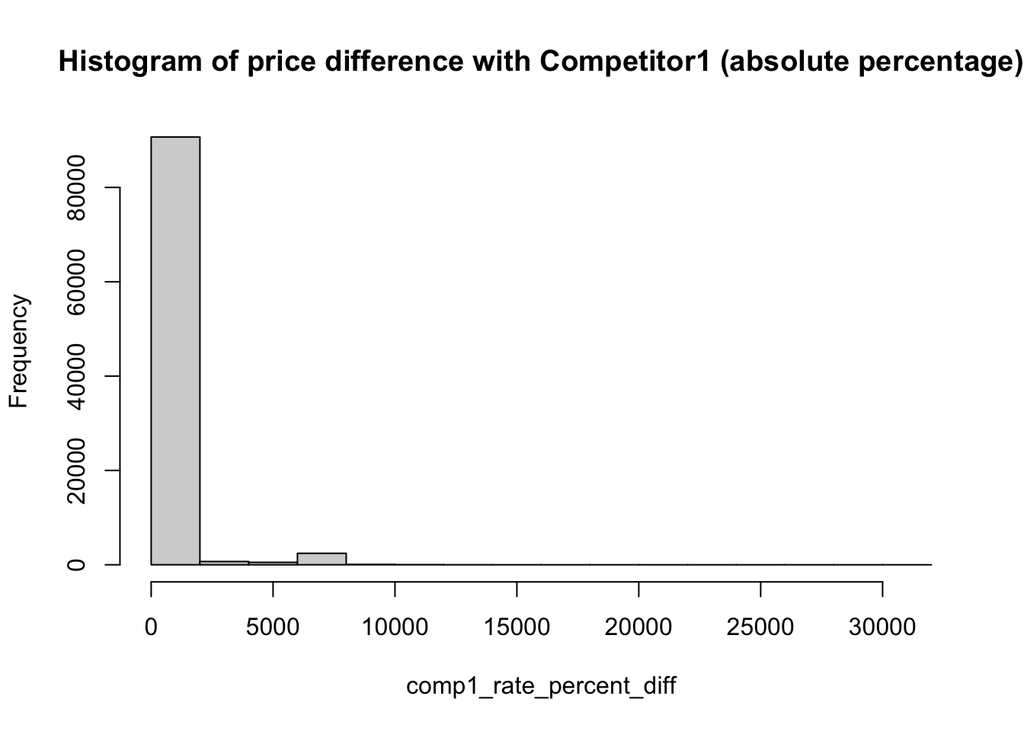

*Observations:* 98.1% of values are NULL. Of the non-NULL values: absolute price difference ranges between 2 and 30389 *Questions:* If this is a percentage value why do we have a maximum of 30389?? (Guido’s answer: “This is definitely an error”)

# Training set variables only

## Exploring **position** *Data Type:* Integer *Description:* Hotel position on Expedia’s search results page. This is only provided for the training data, but not the test data

`r range(tr$position)`

`## [1] 1 40`

`r hist(tr$position, main = "Histogram of hotel position on search page")`

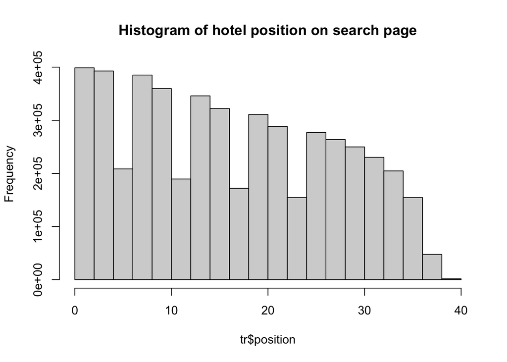

*Observations:* Data ranges from 1 to 40. Histogram has a distinct pattern. *TODO:* look into why the histogram has this particular pattern.

## Exploring **click_bool**

*Data Type:* Boolean *Description:* 1 if the user clicked on the property, 0 if not

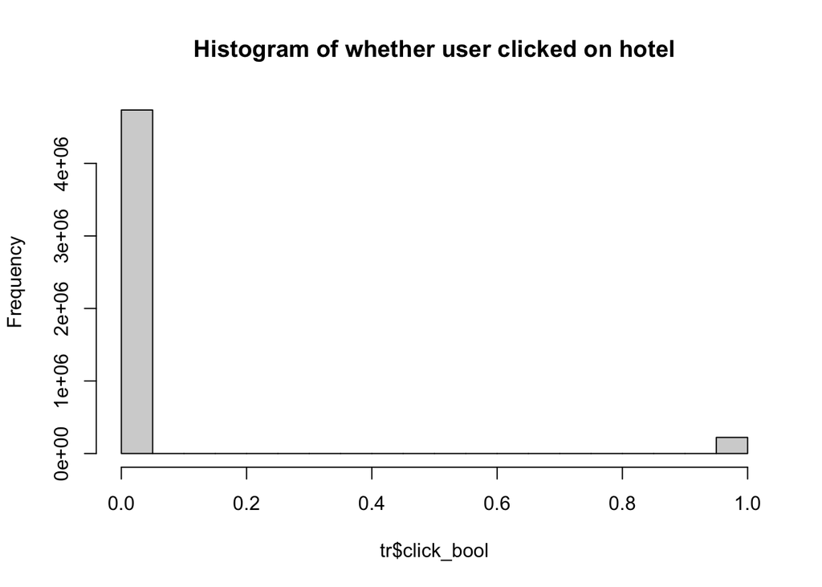

```r
hist(tr$click_bool, main = "Histogram of whether user clicked on hotel")
```

```r
click_bool_yes <- subset(tr$click_bool, tr$click_bool == 1)
click_bool_no <- subset(tr$click_bool, tr$click_bool == 0)

nrow(as.matrix(click_bool_yes))  # 221879
```

```
## [1] 221879
```

```r
nrow(as.matrix(click_bool_no))   # 4736468
```

```
## [1] 4736468
```

```r
221879 / tr_row * 100  # 4.474858
```

```
## [1] 4.474858
```

```r
4736468 / tr_row *100  # 95.52514
```

```
## [1] 95.52514
```

*Observations:* 95.5% of searches did not result in the user clicking on a particular hotel

## Exploring **booking_bool** *Data Type:* Boolean *Description:* 1 if the user booked the property, 0 if not

`r hist(tr$booking_bool, main = "Histogram of whether user clicked on hotel")`

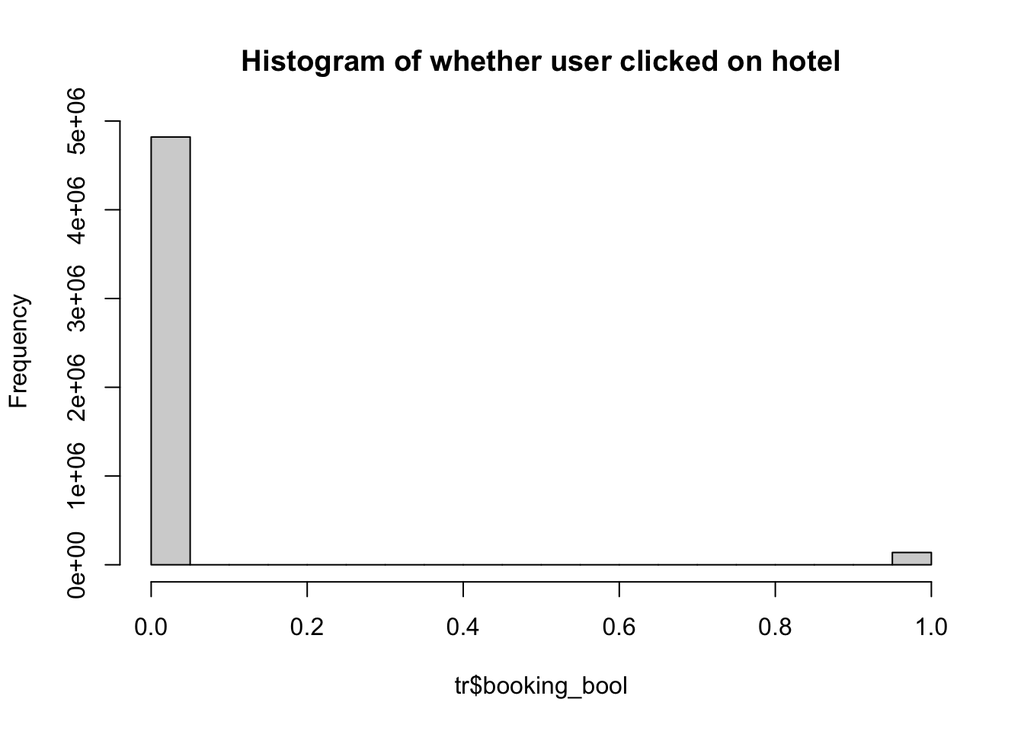

```r booking_bool_yes <- subset(tr$booking_bool, tr$booking_bool == 1) booking_bool_no <- subset(tr$booking_bool, tr$booking_bool == 0)

nrow(as.matrix(booking_bool_yes)) # 138390 ```

`## [1] 138390`

`r nrow(as.matrix(booking_bool_no)) # 4819957`

`## [1] 4819957`

`r 138390 / tr_row * 100 # 2.791051`

`## [1] 2.791051`

`r 4819957 / tr_row * 100 # 97.20895`

`## [1] 97.20895` *Observations:* 97.2% of searches did not result in the user booking a particular hotel

## Exploring **gross_booking_usd**

*Data Type:* Float *Description:* Total value of the transaction. This can differ from the price_usd due to taxes, fees, conventions on multiple day bookings and purchase of a room type other than the one shown in the search

```r
gbu <- subset(tr$gross_bookings_usd, tr$gross_bookings_usd != "NULL")
gbu <- as.numeric(gbu)
range(gbu)
```

```
## [1]      0.0 159292.4
```

```r
head(sort(subset(gbu, gbu > 0)))
```

```
## [1] 0.30 0.70 0.97 0.98 1.00 1.16
```

```r
tail(sort(subset(gbu, gbu < 10000)))
```

```
## [1] 9474.44 9539.10 9608.97 9660.78 9904.05 9926.01
```

```r
tail(sort(subset(gbu, gbu < 1000)))
```

```
## [1] 999.85 999.87 999.87 999.90 999.93 999.99
```

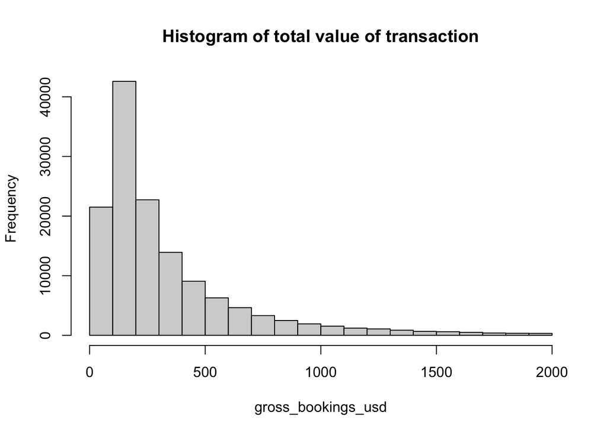

```r
gbu_2k <- subset(gbu, gbu < 2000)
hist(gbu_2k, xlab = "gross_bookings_usd", main = "Histogram of total value of transaction")
```

*Observations:* Data is made up of 97.2% NULL values. Of the remaining values the range is from 0.0 to 159292.4. The vast majority of values are around 200 USD. Histogram excludes NULL values. This data will definitely need some cleaning up! *Questions:* What do the NULL values mean? Is NULL generated when the search does not result in a booking? If that is the case, then what does 0 mean? How is a value like 0.30 possible, for example? (Guido’s answer: “here I would assume that NULL means no data available and 0 means the property was not booked”)